# Introduction à R

Ecole de Bioinformatique Aviesan-IFB 2018

Hugo Varet, Olivier Kirsh et Jacques van Helden

2019-01-15

## Se connecter au serveur RStudio de Roscoff

http://r.sb-roscoff.fr/auth-sign-in

## Aller dans son dossier de travail

Définir une variable qui indique le chemin du dossier de travail

```r
work.dir <- "~/intro_R"
```

S’il n’existe pas encore, créer le dossier de travail. (Commande Unix équivalente: "mkdir -p ~/intro_R")

```r
dir.create(work.dir, recursive = TRUE, showWarnings = FALSE)
```

Aller dans ce dossier de travail. (Commande Unix équivalente: "cd ~/intro_R")

```r
setwd(work.dir)
```

Où suis-je ? (Commande Unix équivalente: "pwd")

```r
getwd()
```

Qu'y a-t-il par ici ? (Commande Unix équivalente: "ls")

```r
list.files()
```

## R vu comme une calculatrice

```r
2 + 3
4 * 5
6 / 4
```

## Notion de variable/objet

```r
a <- 2      ## Assigner une valeur à une variable
print(a)    ## Afficher la valeur de la variable a
```

```r
b <- 3      ## Assigner une valeur à une seconde variable
c <- a + b  ## Effectuer un calcul avec 2 variables
print(c)    ## Afficher le contenu de la variable c
```

```r
a <- 7      ## Changer la valeur de a
print(c)    ## Note: le contenu de c n'est pas modifié
```

## Télécharger un fichier

```r
## download.file(url = "https://goo.gl/9QVAg6", destfile = "expression.txt")
```

```r
## download.file(url = "https://goo.gl/NQWnHg", destfile = "annotation.csv")
```

## Chargement des données

Charger le contenu du fichier "expression.txt" dans une variable nommée "exprs".

```r
exprs <- read.table(file = "expression.txt", header = TRUE, sep = "\t")
```

Accéder à l'aide d'une fonction

```r
help(read.table)
```

Notation alternative

```r
?read.table
```

## Affichage de l'objet "exprs"

Imprimer toutes les valeurs.

```r
print(exprs)
```

```
                id    WT1   WT2    KO1   KO2
1  ENSG00000034510 235960 94264 202381 91336
2  ENSG00000064201    116    71     64    56
3  ENSG00000065717    118   174    124   182
4  ENSG00000099958    450   655    301   472
5  ENSG00000104164   4736  5019   4845  4934
6  ENSG00000104783   9002  8623   7720  7142
7  ENSG00000105229   1295  2744   1113  2887
8  ENSG00000105723   3353  7449   3589  7202
9  ENSG00000116199   2044  4525   2604  4902
10 ENSG00000118939   7022  2526   6269  3068
11 ENSG00000119285  15783 17359  18591 20077
12 ENSG00000121680   3133  2775   2045  2796
13 ENSG00000125384   1380  3079    869  2419
14 ENSG00000129562  12089  7958  10708  7683
```

[output cut: 36 more lines]

## Affichage des premières lignes de l'objet

```r
head(exprs)
```

```
               id    WT1   WT2    KO1   KO2
1 ENSG00000034510 235960 94264 202381 91336
2 ENSG00000064201    116    71     64    56
3 ENSG00000065717    118   174    124   182
4 ENSG00000099958    450   655    301   472
5 ENSG00000104164   4736  5019   4845  4934
6 ENSG00000104783   9002  8623   7720  7142
```

## Un peu plus de lignes

```r
head(exprs, n = 15)
```

```
                id    WT1   WT2    KO1   KO2
1  ENSG00000034510 235960 94264 202381 91336
2  ENSG00000064201    116    71     64    56
3  ENSG00000065717    118   174    124   182
4  ENSG00000099958    450   655    301   472
5  ENSG00000104164   4736  5019   4845  4934
6  ENSG00000104783   9002  8623   7720  7142
7  ENSG00000105229   1295  2744   1113  2887
8  ENSG00000105723   3353  7449   3589  7202
9  ENSG00000116199   2044  4525   2604  4902
10 ENSG00000118939   7022  2526   6269  3068
11 ENSG00000119285  15783 17359  18591 20077
12 ENSG00000121680   3133  2775   2045  2796
13 ENSG00000125384   1380  3079    869  2419
14 ENSG00000129562  12089  7958  10708  7683
15 ENSG00000129932   1744  2247   1513  3104
```

## Caractéristiques d'un tableau

Dimensions

```r
dim(exprs)    ## Dimensions
ncol(exprs)   ## Nombre de colonnes
nrow(exprs)   ## Nombre de lignes
```

Noms des lignes et colonnes

```r
colnames(exprs)
rownames(exprs)
```

## Résumé rapide des données par colonne

```r
  summary(exprs)
```

```
               id          WT1              WT2               KO1                KO2
 ENSG00000034510: 1   Min.   :    31   Min.   :   43.0   Min.   :    30.0   Min.   :   16.0
 ENSG00000064201: 1   1st Qu.:   264   1st Qu.:  203.2   1st Qu.:   228.5   1st Qu.:  223.5
 ENSG00000065717: 1   Median :  1338   Median : 1903.0   Median :  1324.5   Median : 2060.0
 ENSG00000099958: 1   Mean   :  9358   Mean   : 6498.6   Mean   :  8356.0   Mean   : 6489.5
 ENSG00000104164: 1   3rd Qu.:  3730   3rd Qu.: 4727.2   3rd Qu.:  3491.2   3rd Qu.: 4926.0
 ENSG00000104783: 1   Max.   :235960   Max.   :94264.0   Max.   :202381.0   Max.   :91336.0
 (Other)        :44
```

## Sélection de colonnes d'un tableau

Valeurs stockées dans la colonne nommée "WT1"

```r
exprs$WT1
```

Notation alternative

```r
exprs[, "WT1"]  ## Sélection de la colonne WT1
```

Sélection de plusieurs colonnes.

```r
exprs[, c("WT1", "WT2")]
```

Sélection de colonnes par leur indice

```r
exprs[, 2]
exprs[, c(2, 3)]
```

## Histogramme des valeurs d'expression pour WT1

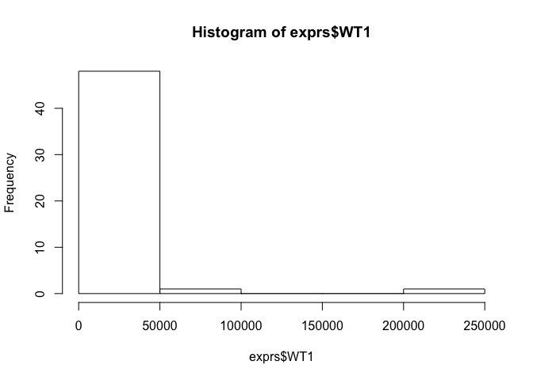

```r
hist(exprs$WT1)
```

## Histogramme du logarithme de ces valeurs

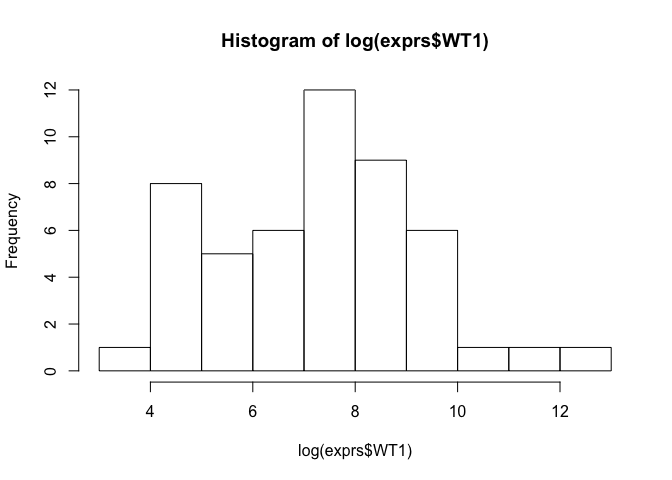

```r
hist(log(exprs$WT1))
```

## Nuages de points -- Expressions KO1 vs WT1

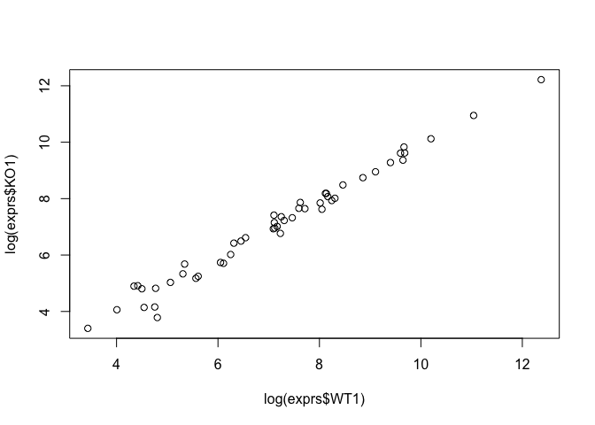

```r
plot(x = log(exprs$WT1), y = log(exprs$KO1))
```

## Personnalisation des paramètres graphiques

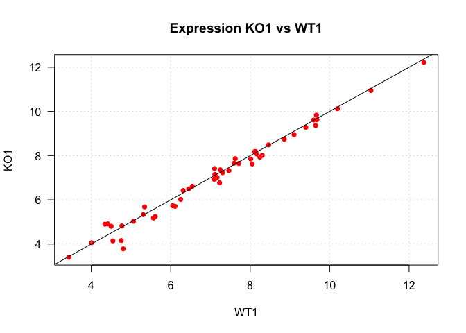

```r
plot(x = log(exprs$WT1),   ## données pour l’abscisse
     y = log(exprs$KO1),   ## données pour l’ordonnée
     main = "Expression KO1 vs WT1",  ## Titre principal
     xlab = "WT1",  ## légende de l’axe X
     ylab = "KO1",  ## légende de l’axe Y
     pch = 16,      ## caractère pour marquer les points
     las = 1,       ## écrire les échelles horizontalement
     col = "red")   ## couleur des points
grid()  ## Ajout d’une grille
abline(a = 0, b = 1)   ## Ajouter la droite X = Y (intercept a = 0, pente b = 1).
```

## Sélection de lignes d'un tableau

Sélection des lignes 4 et 11 du tableau des expressions

```r
exprs[c(4, 11), ]
```

Indices des lignes correspondant aux IDs ENSG00000253991 et ENSG00000099958

```r
which(exprs$id %in% c("ENSG00000253991", "ENSG00000099958"))
```

Afficher les lignes correspondantes

```r
exprs[which(exprs$id %in% c("ENSG00000253991", "ENSG00000099958")), ]
```

## Calculs sur des colonnes

Calcul de moyennes par ligne (`rowMeans`) pour un sous-ensemble donné des colonnes (WT1 et WT2).

```r
rowMeans(exprs[,c("WT1","WT2")])
```

Ajout de colonnes avec les expressions moyennes des WT et des KO.

```r
exprs$meanWT <- rowMeans(exprs[,c("WT1","WT2")])
exprs$meanKO <- rowMeans(exprs[,c("KO1","KO2")])

head(exprs) ## Check the result
```

Fold-change KO vs WT

```r
exprs$FC <- exprs$meanKO / exprs$meanWT
head(exprs) ## Check the result
```

Moyenne de tous les échantillons

```r
exprs$mean <- rowMeans(exprs[,c("WT1","WT2","KO1","KO2")])
```

## MA-plot: log2FC vs intensité

$M$ est le logarithme en base 2 du rapport d'expression.

$$M = log_{2} (\text{FC}) = log_{2} \left( \frac{\text{KO}}{\text{WT}} \right) = log_2 (\text{KO}) - log_2(\text{WT})$$

```r
exprs$M <- log2(exprs$FC)
```

$A$ (average intensity) est la moyenne des logarithmes des valeurs d'expression.

$$A = \frac{1}{2} log_2 (\text{KO} \cdot \text{WT}) = \frac{1}{2} \left( log_2 (\text{KO}) + log_2(\text{WT}) \right)$$

```r
exprs$A <- rowMeans(log2(exprs[,c("meanWT", "meanKO")]))
```

## MA-plot: log2FC vs intensité

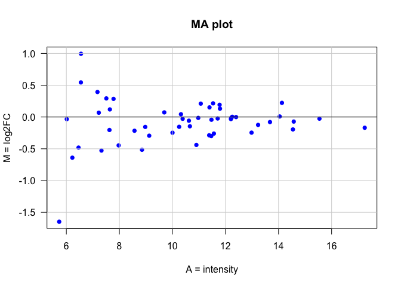

```r
plot(x = exprs$A, y = exprs$M, main = "MA plot", las = 1,
     col = "blue", pch = 16, xlab = "A = intensity", ylab = "M = log2FC")
grid(lty = "solid", col = "lightgray")
abline(h = 0)
```

## Charger les annotations des gènes

```r
annot <- read.table(file = "annotation.csv", header = TRUE, sep = ";")
dim(annot)   ## Vérifier les dimensions
head(annot)  ## Afficher quelques lignes
```

Combien de gènes par chromosome ?

```r
table(annot$chr)
```

Question: combien de gènes sur le chromosome 8 ? Et sur le X ?

## Diagramme en bâtons -- gènes par chromosomes

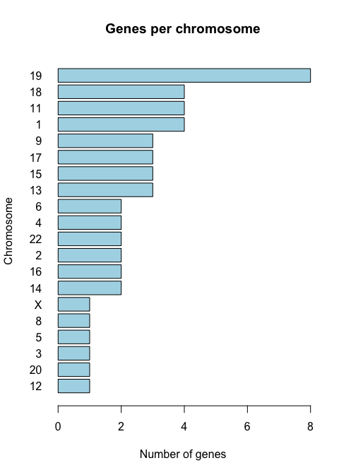

```r
barplot(sort(table(annot$chr)), horiz = TRUE, las = 1,
        main = "Genes per chromosome", ylab = "Chromosome",
        col = "lightblue", xlab = "Number of genes")
```

## Sélectionner les données du chromosome 8

1ere étape: fusionner les deux tableaux exprs et annot

```r
exprs.annot <- merge(exprs, annot, by = "id")
head(exprs.annot)
```

2eme étape: sous-ensemble des lignes pour lesquelles chr vaut 8

```r
exprs8 <- exprs.annot[which(exprs.annot$chr == 8),]
print(exprs8)
```

## Exporter exprs8 dans un fichier

```r
write.table(x = exprs8, file = "exprs8.txt", sep = "\t",
            row.names = TRUE, col.names = NA)
```

## A ajouter: ALLER PLUS LOIN (optionnel)

- charger un tableau complet de données (RNA-seq ou ChIP-seq et refaire quelques plots)
- hist(breaks = 100)
- apply
- sort, order
- lm() ?